# Intro to R

Day 2

Class date: 01/24/2017 Last update: 09/14/17

# 1 knitr

## 1.1 .R scripts

We can create a reproducible document from a .R script using `spin()`

## 1.2 .Rmd files

When we want to generate a report that will include prose, an `RMarkdown` document (.Rmd) is probably better.

### 1.2.1 yaml front matter

Some important details about our document are contained in the yaml front matter. It is the section at the top of the document that looks like this:

```
---
title: 'title here'
output: html_document
---
```

We can change the type of document to .doc (`output: word_document`) or .pdf (`output: pdf_document`).

### 1.2.2 Code chunks

If we want to include R code in our .Rmd file, we must use code chunks. An R code chunk begins with 3 backticks ```, curly braces containing the letter “r”, followed by our code. The chunk is closed with 3 more backticks. Ex.

````
```{r}
2 + 2
```
````

### 1.2.3 Inline code

If we want to evaluate an R expression inside of prose, we can use the following syntax:

```r
    Inline code looks like this `r 2 + 2`
```

This is an example. Two plus two equals 4.

# 2 Data structures (cont.)

## 2.1 Assignment

We can assign values to objects using the assignment operator `<-`.

```r
# Assign value 5 to 'object'
object <- 5

# print 'object'
print(object)
```

```
## [1] 5
```

```r
# Add 5 to 'object'
object + 5
```

```
## [1] 10
```

## 2.2 Vectors (cont.)

The most basic data structure is the vector. Vectors have types (numeric, character, etc.). If we want to create a vector with a length larger than 1, we can use the `c()` function (concatenate).

```r
# assigning variables
x <- c(1, 2, 6, 3, 7)
y <- c("a", "b", "c", "d", "e")

# print them
print(x)
```

```
## [1] 1 2 6 3 7
```

```r
print(y)
```

```
## [1] "a" "b" "c" "d" "e"
```

Vectorized math works the same as an object of length 1 (compare with `object + 5` above).

```r
x + 20
```

```
## [1] 21 22 26 23 27
```

## 2.3 Dataframes

A dataframe is a two dimensional object made of columns and rows. The columns have names and can be of different types; however, all columns must have the same length. We can create a dataframe using the `data.frame()` function.

```r
# creating dataframes
df <- data.frame(x, y)

print(df)
```

```
##   x y
## 1 1 a
## 2 2 b
## 3 6 c
## 4 3 d
## 5 7 e
```

We can get information about a dataframe using `str()`, `head()`, `tail()`, and `dim()`.

```r
# Exploring objects
str(df)
```

```
## 'data.frame':    5 obs. of  2 variables:
##  $ x: num  1 2 6 3 7
##  $ y: Factor w/ 5 levels "a","b","c","d",..: 1 2 3 4 5
```

```r
head(cars)
```

```
##   speed dist
## 1     4    2
## 2     4   10
## 3     7    4
## 4     7   22
## 5     8   16
## 6     9   10
```

```r
tail(cars)
```

```
##    speed dist
## 45    23   54
## 46    24   70
## 47    24   92
## 48    24   93
## 49    24  120
## 50    25   85
```

```r
dim(cars)
```

```
## [1] 50  2
```

## 2.4 Lists

A list is a data structure that can cantain any type of object.

```r
myList <- list(a = 1:3, b = 'abc', c = TRUE)
str(myList)
```

```
## List of 3
##  $ a: int [1:3] 1 2 3
##  $ b: chr "abc"
##  $ c: logi TRUE
```

You will probably not use lists too much, but it is a good idea to understand how they work in order to have a better understanding of R syntax.

# 3 Subsetting

## 3.1 Subsetting vectors

We can subset a vector using brackets (`[]`). Given that a vector is a 1D object, the number we include in the bracket refers to the position in the vector. In other words, if we want to see the first element of `x`. We can use the bracket notations `x[1]`.

```r
x[1]
```

```
## [1] 1
```

## 3.2 Subsetting dataframes

Subsetting a dataframe works in the same way; however, since the structure has two dimensions, it is necessary to give information about both. We will still use the bracket notations, but we will designate `rows` and `columns` by separating them with a comma.

```r
# First row, all columns
df[1, ]
```

```
##   x y
## 1 1 a
```

```r
# Secont row, first column
df[2, 1]
```

```
## [1] 2
```

```r
# rows 1 to 3, all columns
df[1:3, ]
```

```
##   x y
## 1 1 a
## 2 2 b
## 3 6 c
```

We can also subset using the names of the columns:

```r
# Give me the first 10 values of
# 'speed' in the 'cars' data frame
cars$speed[1:10]
```

```
##  [1]  4  4  7  7  8  9 10 10 10 11
```

```r
# another way
cars[1:10, 'speed']
```

```
##  [1]  4  4  7  7  8  9 10 10 10 11
```

## 3.3 Subsetting lists

We can single out an element of a list using bracket notation (like with a vector). This will return another list.

```r
# Give me the first element
myList[1]
```

```
## $a
## [1] 1 2 3
```

```r
# Show me the structure of the first element
str(myList[1])
```

```
## List of 1
##  $ a: int [1:3] 1 2 3
```

This may not always be useful. For example, is the first element is a vector, we may want it as a vector (and not a list). In order to subset an element of a list and get it in its `natural` state, we can use double brackets (Note: this is useful if you need to perform an operation on something in a list).

```r
# Give me the first element (not as a list)
myList[[1]]
```

```
## [1] 1 2 3
```

```r
# Show me the structure
str(myList[[1]])
```

```
##  int [1:3] 1 2 3
```

We can also refer to the names of the objects inside the list directly (if they have names).

```r
myList['a']
```

```
## $a
## [1] 1 2 3
```

```r
myList[['a']]
```

```
## [1] 1 2 3
```

We can also subset a subset of a list (what?). For example, the first element of `myList` is the vector `a`. We can obtain the second values of `a` like this:

```r
myList[['a']][2]
```

```
## [1] 2
```

# 4 Descriptive statistics

We can calculate descriptive statistics on vectors. Some handy functions are:

- `sum()`
- `mean()`
- `sd()`
- `abs()`

```r
# Mean of 'x'
mean(x)
```

```
## [1] 3.8
```

```r
# Sum of 'x'
sum(x)
```

```
## [1] 19
```

We can also do this using data frames or lists.

```r
# Mean of 'x' in dataframe 'df'
mean(df$x)
```

```
## [1] 3.8
```

```r
# SD of 'x' in dataframe 'df'
sd(df$x)
```

```
## [1] 2.588436
```

```r
# Sum of 'a' is list 'myList' (double brackets are obligatory)
sum(myList[['a']])
```

```
## [1] 6
```

```r
# SD 'speed' in 'cars'
sd(cars$speed)
```

```
## [1] 5.287644
```

```r
sd(cars[, 'speed'])
```

```
## [1] 5.287644
```

```r
# Mean of first 15 rows of the first column
mean(cars[1:15, 1])
```

```
## [1] 9.266667
```

```r
mean(cars$speed[1:15])
```

```
## [1] 9.266667
```

```r
mean(cars$speed[c(1, 2, 3, 4, 5, 6, 7, 8, 9, 10, 11, 12, 13, 14, 15)])
```

```
## [1] 9.266667
```

The `aggregate()` function is extremely handy. You provide a formula, the function you would like to apply, and the dataframe. For example, consider the `iris` dataset.

```r
str(iris)
```

```
## 'data.frame':    150 obs. of  5 variables:
##  $ Sepal.Length: num  5.1 4.9 4.7 4.6 5 5.4 4.6 5 4.4 4.9 ...
##  $ Sepal.Width : num  3.5 3 3.2 3.1 3.6 3.9 3.4 3.4 2.9 3.1 ...
##  $ Petal.Length: num  1.4 1.4 1.3 1.5 1.4 1.7 1.4 1.5 1.4 1.5 ...
##  $ Petal.Width : num  0.2 0.2 0.2 0.2 0.2 0.4 0.3 0.2 0.2 0.1 ...
##  $ Species     : Factor w/ 3 levels "setosa","versicolor",..: 1 1 1 1 1 1 1 1 1 1 ...
```

```r
head(iris)
```

```
##   Sepal.Length Sepal.Width Petal.Length Petal.Width Species
## 1          5.1         3.5          1.4         0.2  setosa
## 2          4.9         3.0          1.4         0.2  setosa
## 3          4.7         3.2          1.3         0.2  setosa
## 4          4.6         3.1          1.5         0.2  setosa
## 5          5.0         3.6          1.4         0.2  setosa
## 6          5.4         3.9          1.7         0.4  setosa
```

Let’s pretend we are interested in the `Sepal.Length` (column 1). We notice that the `str()` function indicates that there is a factor called `Species` that has three levels (“setosa”, “versicolor”, “virginica”). Let’s calculate the mean `Sepal.Length` for each level of `Species`. A simple way to do that is to use `aggregate()`.

```r
# Mean Sepal.Length as a function of Species
aggregate(Sepal.Length ~ Species, FUN = mean, data = iris)
```

```
##      Species Sepal.Length
## 1     setosa        5.006
## 2 versicolor        5.936
## 3  virginica        6.588
```

# 5 Coercion

We can change the class of an object through coercion.

- as.data.frame()
- as.numeric(y)
- as.character(x)
- as.factor()

# 6 Data sets

R is installed with a number of data sets that can be used to practice. To see them use `data()`. Here are the first 60…

```
##  [1] "AirPassengers"          "BJsales"
##  [3] "BJsales.lead (BJsales)" "BOD"
##  [5] "CO2"                    "ChickWeight"
##  [7] "DNase"                  "EuStockMarkets"
##  [9] "Formaldehyde"           "HairEyeColor"
## [11] "Harman23.cor"           "Harman74.cor"
## [13] "Indometh"               "InsectSprays"
## [15] "JohnsonJohnson"         "LakeHuron"
## [17] "LifeCycleSavings"       "Loblolly"
## [19] "Nile"                   "Orange"
## [21] "OrchardSprays"          "PlantGrowth"
## [23] "Puromycin"              "Seatbelts"
## [25] "Theoph"                 "Titanic"
## [27] "ToothGrowth"            "UCBAdmissions"
## [29] "UKDriverDeaths"         "UKgas"
## [31] "USAccDeaths"            "USArrests"
## [33] "USJudgeRatings"         "USPersonalExpenditure"
## [35] "UScitiesD"              "VADeaths"
## [37] "WWWusage"               "WorldPhones"
## [39] "ability.cov"            "airmiles"
## [41] "airquality"             "anscombe"
## [43] "attenu"                 "attitude"
## [45] "austres"                "beaver1 (beavers)"
## [47] "beaver2 (beavers)"      "cars"
## [49] "chickwts"               "co2"
## [51] "crimtab"                "discoveries"
## [53] "esoph"                  "euro"
## [55] "euro.cross (euro)"      "eurodist"
## [57] "faithful"               "fdeaths (UKLungDeaths)"
## [59] "freeny"                 "freeny.x (freeny)"
```

# 7 Basic bivariate plot

We can create a bivariate scatterplot using the function `biVarPlot()` from the package `lingStuff`.

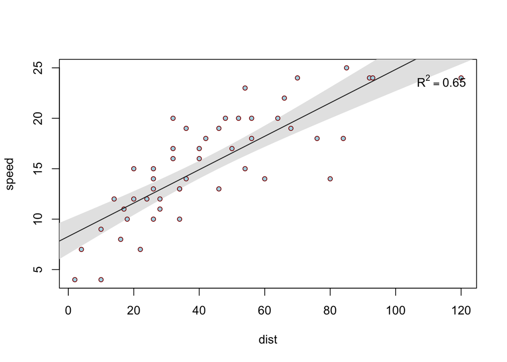

```
##
## Call:
## lm(formula = dv ~ iv)
##
## Residuals:
##     Min      1Q  Median      3Q     Max
## -7.5293 -2.1550  0.3615  2.4377  6.4179
##
## Coefficients:
##             Estimate Std. Error t value Pr(>|t|)
## (Intercept)  8.28391    0.87438   9.474 1.44e-12 ***
## iv           0.16557    0.01749   9.464 1.49e-12 ***
## ---
## Signif. codes:  0 '***' 0.001 '**' 0.01 '*' 0.05 '.' 0.1 ' ' 1
##
## Residual standard error: 3.156 on 48 degrees of freedom
## Multiple R-squared:  0.6511, Adjusted R-squared:  0.6438
## F-statistic: 89.57 on 1 and 48 DF,  p-value: 1.49e-12
```

```r
library(lingStuff)
biVarPlot(data = cars, x = dist, y = speed, family = 'Gaussian')
```

In base R we can do the same using the `plot()` function.

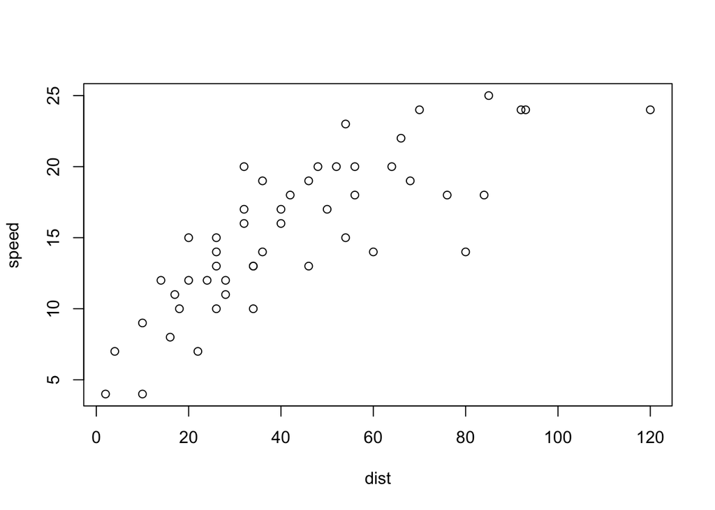

```r
plot(speed ~ dist, data = cars)
```